# Homework 6 Solutions

# Part 1

Using the bootstrap We will use the bootstrap technique to generate confidence intervals

Suppose we have a sample of data from an exponential distribution with parameter lambda. In this case use lambda.hat = 1/mean(X).

As the number of observations increases, this estimate for lambda becomes normally distributed.

1a. (1) Generate 100 observations of test data, with lambda=3. Remember to set your seed before carrying out any computations.

```r
set.seed(0)
my.Test.Data<-rexp(100,3)
```

1b. (1) What is the mean of your test data?

```r
mean(my.Test.Data)
```

```
## [1] 0.344049
```

1c. (1) What is your estimate lambda.hat?

```r
1/mean(my.Test.Data)
```

```
## [1] 2.906563
```

```r
empirical.lambda<-1/mean(my.Test.Data)
```

# Part 2

Now use the bootstrap to estimate the distribution of lambda.hat and create bootstrap confidence intervals for lambda, rather than the approach in 1).

2a. (1) Form a set of bootstrap estimates of our parameter by generating B random samples as you did once in 1a but use lambda.hat since we do not know the true lambda in this case (keep n=100). Set B=1000, and again set your seed.

```r
set.seed(0) #any value is ok
B = 1000
1/mean(rexp(100,empirical.lambda))
```

```
## [1] 2.816036
```

2b. (1) Get a new estimate for lambda.hat from each of the bootstrap samples in 2a. You’ll want to create a matrix to receive each value. You should have 1000 estimates for lambda.hat now.

```r
boot.sampling.dist<-rep(0,B)

for (i in 1:B){
  boot.sampling.dist[i]<-1/mean(rexp(100,empirical.lambda))
}
```

2c. (2) Now look at the sampling distribution for lambda.hat, using the hist function. Remember your graphing techniques to make the plot look professional. Does the distribution look normal?

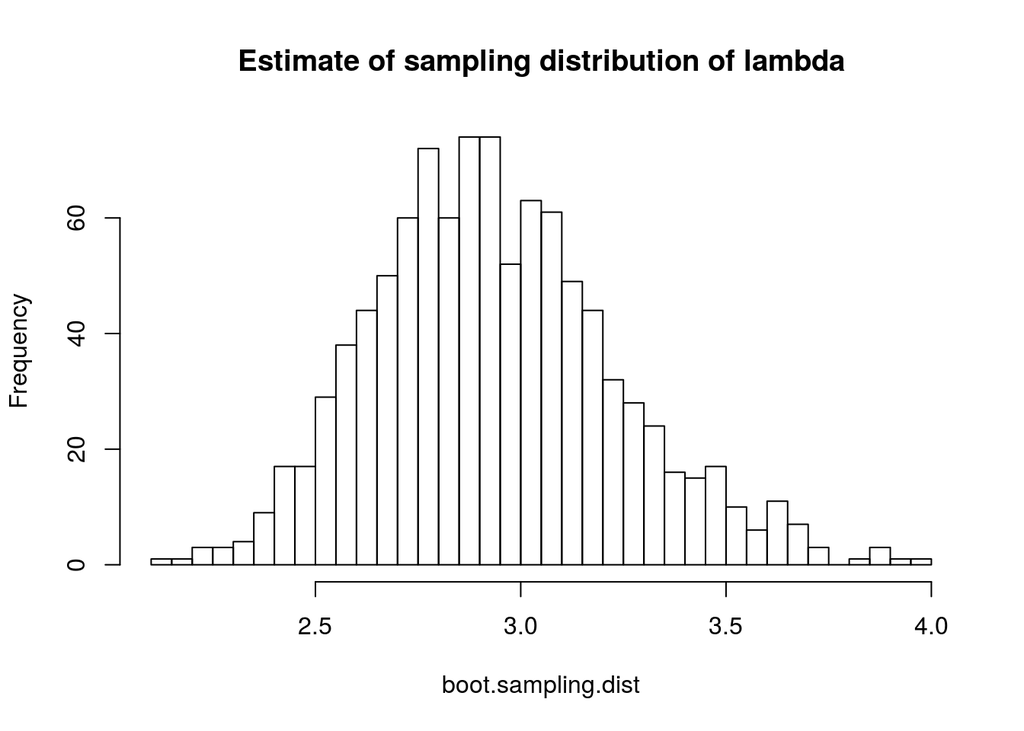

```r
hist(boot.sampling.dist,main="Estimate of sampling distribution of lambda",breaks=50)
```

2d. (1) Calculate an estimate of the standard error of lambda.hat using your collection of bootstrap estimated parameters. What is your confidence interval?

```r
boot.estimate.se<-sqrt(var(boot.sampling.dist))
c(mean(boot.sampling.dist)-1.96*boot.estimate.se,mean(boot.sampling.dist)+1.96*boot.estimate.se)
```

```
## [1] 2.351302 3.520257
```

# Part 3

3a. (5) We made some decisions when we used the bootstrap above that we can now question. Repeat the above creation of a confidence interval for a range of values of data (we had our sample size fixed at 100) and a range of bootstrap values (we had B fixed at 1000). Suppose the sample size varies (100, 200, 300, …. , 1000) and B varies (1000, 2000, … , 10000). You will likely find it useful to write functions to carry out these calculations. Your final output should be upper and lower pairs for the confidence intervals produced using the bootstrap method for each value of sample size and B.

generalize 2b into a function, and vary inputs of sample size and B

```r
boot.sample <- function(sample.size, B){
 boot.sample<-matrix(1,B)
 for (i in 1:B){
   boot.sample[i]<-1/mean(rnorm(sample.size,empirical.lambda))
 }
 return(boot.sample)
}
sample.size.v <- seq(1:10)*100
B.v <- seq(1:10)*1000

sampling.l<-lapply(sample.size.v, function(sample.size) {lapply(B.v, function(B) boot.sample(sample.size, B))})

quantile.l<-lapply(sampling.l, function(l) lapply(l, function(v) quantile(v,c(.025,0.975))))

result<-array(unlist(quantile.l), c(2,10,10), list(c("lower", "upper"), B.v, sample.size.v))
```

3b. (2) Plot your CI limits to show the effect of changing the sample size and changing the number of bootstrap replications. What do you conclude?

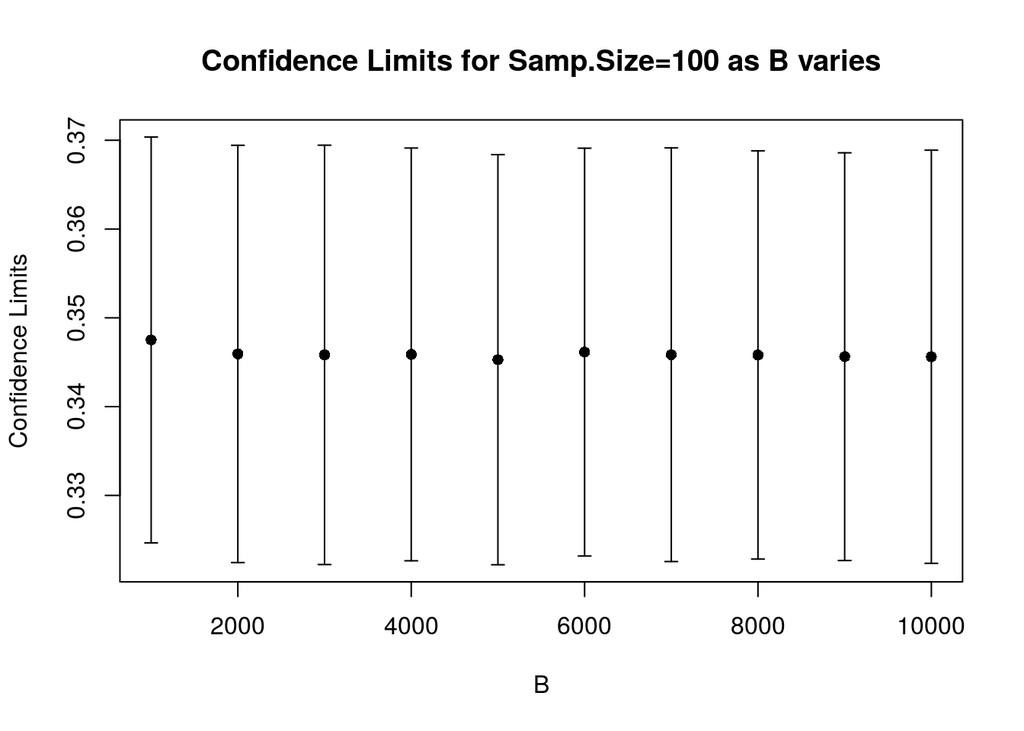

```r
library(Hmisc)
samp_size100 <- result[,,1]
lower <- samp_size100[1,]
upper <- samp_size100[2,]
samp_means <- apply(samp_size100,MARGIN=2,mean)
errbar(x=seq(1000,10000,by=1000),y=samp_means,yplus=upper,yminus=lower,xlab="B",ylab="Confidence Limits")
title("Confidence Limits for Samp.Size=100 as B varies")
```

[figure not shown]

```r
B100 <- result[,1,]
lower <- B100[1,]
upper <- B100[2,]
samp_means <- apply(B100,MARGIN=2,mean)
errbar(x=seq(100,1000,by=100),y=samp_means,yplus=upper,yminus=lower,xlab="Sample Size",ylab="Confidence Limits")
title("Confidence Limits for B=100 as samp.size varies")
```

[output not shown]

As we increase our sample size, we see that our confidence limits become smaller, and therefore we are more confident in our parameter estimate.

However, increasing B does not impact our confidence limits. Intuitively, if we start with a small sample, there is likely a lot of variance in the data, and we are less certain that we are accurately capturing the true population distribution. Since bootstrapping is simply taking this original dataset and repeatedly resampling it, we aren’t adding any new information to make our sample closer to the population distribution. The “bad” sample is just being re-created many times.

A common mistake on this problem was the incorrect trend of increasing B and seeing a decrease in confidence limits. This was due to your standard error calculations. The sampling distribution of lambda.hat is found by creating the sample distribution of bootstrap lambda.hats. These lambda.hats are approximately normally distributed, so the standard error is simply $\sigma$. The common mistake was to use $\frac{\sigma}{\sqrt{n}}$ as the standard error. This is not correct because you are now calculating the standard error of the *sample mean* of your bootstrap lambda.hats, when you really want the standard error of the bootstrap lambda.hats. This is why increasing B resulted in a decrease in the CI limits, due to dividing by $\sqrt{n}$.

I understand that this is somewhat confusing, so I only deducted a point if this mix-up occurred. I also took a point off if you only discussed the effect of increasing B and didn’t mention sample size, and vice versa. If you said “increasing sample size *and* B reduces the CI limits” that lost a point as well.

# Part 4

4a. (5) In 1961 John Tukey wrote an article called The Future of Data Analysis (it is uploaded in moodle). Many people say it is prophetic regarding the field of Data Science today. Do you agree or disagee? Why or why not? (Please keep your answer less than 500 words).

4b. (5) Relate the article to the Life Cycle of Data that we discussed in class. You may wish to choose an example or idea from the article and clearly explore how it relates to the Life Cycle of Data. (Please keep your answer less than 500 words).